# homework answers

Heng Liu

2023-11-27

## homework 1

### question 3.2

The standard Laplace distribution has density $f(x)=\frac12e^{-|x|},x\in\mathbb{R}$. Use the inverse transform method to generate a random sample of size 1000 from this distribution.

因为Laplace分布的PDF在$x=0$处发生跳跃，所以需要分开积分。对于$x<0$的部分,$F(x)=\int_{-\infty}^x\frac{1}{2}\exp(x) dx=\frac{1}{2}\exp(x)$,对于$x\geq 0$的部分,$F(x)=\int_{-\infty}^0\frac{1}{2}\exp(x)dx+\int_{0}^x\frac{1}{2}\exp(-x) dx=1-\frac{1}{2}\exp(-x)$。

生成一个随机变量$U\sim U(0,1)$,如果$u<\frac{1}{2}$,那么$u=\frac{1}{2}\exp(x)$，如果$u\geq \frac{1}{2}$,那么,$u=1-\frac{1}{2}\exp(-x)$,因此，逆分布为$\left.x=F^{-1}(u)=\left\{\begin{array}{ll}-\log(2-2u),&\frac{1}{2}\leq u<1\\\log(2u),&0<u<\frac{1}{2}.\end{array}\right.\right.$。

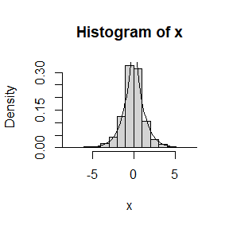

```r
n <- 1000
u <- runif(n)
index <- which(u >= 0.5)
x <- c(-log(2-2 * u[index]), log(2 * u[-index]))
x_neg<-seq(-10,0,0.1)
x_pos<-seq(0,10,0.1)
hist(x,freq = FALSE)
lines(x_neg, 0.5 * exp(x_neg))
lines(x_pos, 0.5 * exp(-x_pos))
```

### question 3.7

Write a function to generate a random sample of size n from the Beta(a, b) distribution by the acceptance-rejection method. Generate a random sample of size 1000 from the Beta(3,2) distribution. Graph the histogram of the sample with the theoretical Beta(3,2) density superimposed.

取$g(x)=1$,那么有$\frac{f(x)}{g(x)}=\frac{\Gamma(a+b)}{\Gamma(a)\Gamma(b)}\frac{x^{a-1}(1-x)^{b-1}}1\leq\frac{\Gamma(a+b)}{\Gamma(a)\Gamma(b)},\quad0<x<1$。记$c=\frac{\Gamma(a+b)}{\Gamma(a)\Gamma(b)}$于是，有$\frac{f(x)}{cg(x)}\leq 1$。生成一个随机变量$U\sim U(0,1)$，如果$u\leq x^{a-1}(1-x)^{b-1}$，则接受$x$，否则就拒绝。

```r
rbeta <- function(n, a, b) {
n <- 1000
k <- 0
y <- numeric(n)
while (k < n) {
  u <- runif(1)
  x <- runif(1)
    if (x^(a - 1) * (1 - x)^(b - 1) > u) {
      k <- k + 1
      y[k] <- x
    }
 }
return(y)
}
```

生成大小为1000，服从$B(3,2)$分布的随机样本。

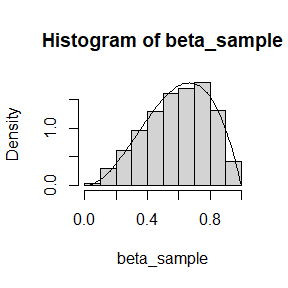

```r
beta_sample<-rbeta(1000,3,2)
hist(beta_sample,freq = F)
y <- seq(0, 1, 0.01)
fy <- 12 * y^2 * (1 - y)
lines(y, fy)
```

### question 3.9

The rescaled Epanechnikov kernel [85] is a symmetric density function $f_e(x)=\frac34(1-x^2),\quad|x|\leq1.$ Devroye and Gy¨orfi [71, p. 236] give the following algorithm for simulation from this distribution. Generate iid $U1, U2, U3 \sim Uniform(−1, 1)$. If $|U3|\geq |U2|$ and $|U3|\geq |U1|$, deliver U2; otherwise deliver U3. Write a function to generate random variates from $f_e$, and construct the histogram density estimate of a large simulated random sample.

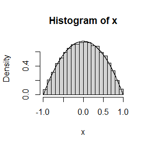

```r
data_gen<-function(n){
  x<-rep(0,n)
  u1<-runif(n,-1,1)
  u2<-runif(n,-1,1)
  u3<-runif(n,-1,1)
  u2index<-which(abs(u3)>=abs(u2)&abs(u3)>=abs(u1))
  u3index<-setdiff(1:n,u2index)
  x[u3index]<-u3[u3index]
  x[u2index]<-u2[u2index]
  return(x)
}

x<-data_gen(10000)
hist(x,freq = F)
a <- seq(-1, 1, 0.001)
fe <- 0.75 * (1 - a^2)
lines(a, fe)
```

### reproduce sample function using inverse transformation method

```r
mysample<-function(data,sample_size,prob){

  # 放回
  # 使用逆变换法生成有放回抽样的索引
  sampled_indices <- integer(sample_size)
  # 生成[0, 1)之间的均匀随机数
  U <- runif(sample_size)
  # 计算累积概率
  cumulative_prob <- cumsum(prob)
  # 找到所在区间
  index <- findInterval(U,cumulative_prob)+1
  # 根据索引获取抽样的数据
  sampled_data <- data[index]
  return(sampled_data)
}

# 测试
# 准备数据集
data <- c("A", "B", "C", "D", "E")
# 指定每个元素的抽样概率
probabilities <- c(0.2, 0.3, 0.1, 0.2, 0.2)


# 放回

# 指定抽样大小
sample_size <- 3
mysample(data=data,sample_size = sample_size,prob = probabilities)
```

```
## [1] "E" "D" "E"
```

## homework 2

### Question 1.2

Take three different values of $\rho$ (0 ≤ $\rho$ ≤ 1, including $\rho_{min}$) and use Monte Carlo simulation to verify your answer. (n = $10^6$, Number of repeated simulations K = 100)

```r
# Calculate the variance of the estimator
pihat.var <- function(rho){
  d <- 1
  l <- d*rho
  n <- 1e6
  M=100 #repeat 100 times
  pihat <- numeric(M)
  for (i in 1:M) {
    X <- runif(n,0,d/2)
    Y <- runif(n,0,pi/2)
    pihat[i] <- 2*l/d/mean(l/2*sin(Y)>X)
  }
  var(pihat)
}
```

Select $\rho=0.5$,$\rho=0.8$, and $\rho=1$to verify

```r
# rho=0.5
pihat.var(0.5)
```

```
## [1] 2.311341e-05
```

```r
# rho=0.8
pihat.var(0.8)
```

```
## [1] 8.618427e-06
```

```r
# rho=1
pihat.var(1)
```

```
## [1] 5.477658e-06
```

We can find that the variance of the estimator decreases as $\rho$ increases, and the variance is minimum when $\rho=1$.

### Ex 5.7

Refer to Exercise 5.6. Use a Monte Carlo simulation to estimate $\theta$ by the antithetic variate approach and by the simple Monte Carlo method. Compute an empirical estimate of the percent reduction in variance using the antithetic variate. Compare the result with the theoretical value from Exercise 5.6.

```r
m <- 10000
simple_mc<-function(){
  m<-1e5
  times<-1e3
  simple_mc<-numeric(times)
  for (i in 1:times) {
    U<-runif(m)
    simple_mc[i]<-mean(exp(U))
  }
  simple_mc
}

anti_variate<-function(){
  m<-1e5
  times<-1e3
  anti_variate<-numeric(times)
  for (i in 1:times) {
    U<-runif(m/2)
    anti_variate[i]<-mean((exp(U)+exp(1-U))/2)
  }
  anti_variate
}

simple_mc_result<-simple_mc()
anti_variate_result<-anti_variate()

# Estimates from both methods
c(mean(simple_mc_result), mean(anti_variate_result))
```

```
## [1] 1.718266 1.718260
```

```r
# Variance of the two methods
c(var(simple_mc_result), var(anti_variate_result))
```

```
## [1] 2.636888e-06 7.872039e-08
```

```r
# Proportion of variance reduction
(var(simple_mc_result) - var(anti_variate_result))/var(simple_mc_result)
```

```
## [1] 0.9701465
```

It can be found that the percent reduction in variance calculated by the simulation is almost the same as the theoretical value.

## homework 3

### 5.13

观察g(x)的函数图，选取如下重要函数： $f_1=2 f(x-1),x>1$,其中$f(x) \sim t(1)$.

$f_2=2\phi(x-1),x>1$,其中$\phi(x) \sim N(0,1)$

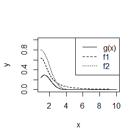

```r
x <- seq(1, 10, 0.01)
y <- x^2 * exp(-x^2/2)/sqrt(2 * pi)
plot(x, y, type = "l",ylim=c(0,1))
lines(x, 2*dt(x-1,df = 1), lty = 2)
lines(x, 2*dnorm(x,mean=1), lty = 3)
legend("topright", legend = c("g(x)", "f1","f2"), lty = 1:3)
```

比较$g(x)/f(x)$的值

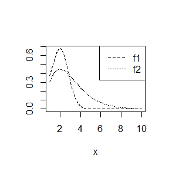

```r
plot(x, y/(2*dt(x-1,df = 1)), type = "l", lty = 2,ylab = "")
lines(x, y/(2*dnorm(x, mean=1)), lty = 3)
legend("topright",  legend = c("f1", "f2"),lty = 2:3)
```

从图中，我们可以得知使用$f_2$作为重要性函数在估计积分时产生较小的方差，因为比值$g(x)/f_2(x)$更接近于常数。

### 5.14

```r
m <- 10000

Importance_sampling1 <- replicate(1000, expr = {
x <- abs(rt(m,df=1))+1
f <- 2*dt(x-1,df=1)
g <- x^2 * exp(-x^2/2)/sqrt(2 * pi)
mean(g/f)
})
Importance_sampling2 <- replicate(1000, expr = {
x <- abs(rnorm(m)) + 1
f <- 2*dnorm(x, mean=1)
g <- x^2 * exp(-x^2/2)/sqrt(2 * pi)
mean(g/f)
})

c(mean(Importance_sampling1), mean(Importance_sampling2))
```

```
## [1] 0.4007031 0.4005945
```

```r
c(var(Importance_sampling1), var(Importance_sampling2))
```

```
## [1] 5.665737e-06 1.933241e-07
```

```r
var(Importance_sampling2)/var(Importance_sampling1)
```

```
## [1] 0.03412161
```

可以看到，在使用$f_2$作为重要函数时产生的方差更小。

### 5.15

分层重要抽样估计

```r
M <- 10000
k <- 5 #层数
m <- M/k #每层样本
theta.hat <- numeric(k)
se <- numeric(k)
g <- function(x) exp(-x)/(1 + x^2)
f <- function(x) (k/(1 - exp(-1))) * exp(-x)
for (j in 1:k) {
u <- runif(m, (j - 1)/k, j/k)
x <- -log(1 - (1 - exp(-1)) * u)
fg <- g(x)/f(x)
theta.hat[j] <- mean(fg)
se[j] <- sd(fg)
}
sum(theta.hat)
```

```
## [1] 0.5247439
```

```r
mean(se)
```

```
## [1] 0.003648978
```

重要抽样(不使用分层抽样)

```r
k <- 1
m <- M/k
theta.hat <- numeric(k)
se <- numeric(k)
for (j in 1:k) {
u <- runif(m, (j - 1)/k, j/k)
x <- -log(1 - (1 - exp(-1)) * u)
fg <- g(x)/f(x)
theta.hat[j] <- mean(fg)
se[j] <- sd(fg)
}
sum(theta.hat)
```

```
## [1] 0.5264051
```

```r
mean(se)
```

```
## [1] 0.09626178
```

可以看到分层重要抽样大大缩减了方差。

### 6.5

```r
n <- 20
t0 <- qt(c(0.025, 0.975), df = n - 1)
CI <- replicate(10000, expr = {
x <- rchisq(n, df = 2)
ci <- mean(x) + t0 * sd(x)/sqrt(n)
})
LCL <- CI[1, ]
UCL <- CI[2, ]
mean(LCL < 2 & UCL > 2)
```

```
## [1] 0.923
```

可以看到，t区间比方差区间(example 6.4: 77.3%覆盖率)更稳健

### 6.A

```r
num_simulations <- 10000
alpha <- 0.05
population_mean <- 1

# 初始化
rejection_count <- rep(0,3)

# Monte Carlo模拟
for (i in 1:num_simulations) {
  # (i) χ²(1)分布
  sample_data_chisq <- rchisq(30, df = 1)
  # (ii) Uniform(0,2)分布
  sample_data_unif <- runif(30, min = 0, max = 2)
  # (iii) 指数分布
  sample_data_exp <- rexp(30, rate = 1)

  # t检验
  t_test_result_chisq <- t.test(sample_data_chisq, mu = population_mean, alternative = "two.sided")
  t_test_result_unif <- t.test(sample_data_unif, mu = population_mean, alternative = "two.sided")
  t_test_result_exp <- t.test(sample_data_exp, mu = population_mean, alternative = "two.sided")
  # 判断是否拒绝零假设
  if (t_test_result_chisq$p.value < alpha) {
    rejection_count[1] <- rejection_count[1] + 1
  }
  if (t_test_result_unif$p.value < alpha) {
    rejection_count[2] <- rejection_count[2] + 1
  }
  if (t_test_result_exp$p.value < alpha) {
    rejection_count[3] <- rejection_count[3] + 1
  }
}

# 计算经验I型错误率
empirical_type_1_error_rate <- rejection_count / num_simulations
cat("Empirical Type I Error Rate:", empirical_type_1_error_rate, "\n")
```

```
## Empirical Type I Error Rate: 0.0904 0.0495 0.0687
```

## homework 4

### question1

```r
# 设置模拟参数
m <- 1000
alpha <- .1 # 显著性水平
# 模拟一千次
rep<- replicate(1000,{
  H0 <- runif(.95*m,0,1)# H0假设的p值，占总数的95%
  H1 <- rbeta(.05*m,.1,1)# H1假设的p值，占总数的5%
  p <- c(H0,H1)
  p.adj1 <- p.adjust(p,method='BH')# Benjamini-Hochberg 校正
  p.adj2 <- p.adjust(p,method='bonferroni')# Bonferroni 校正

  FWER <- FDR <- TPR <- numeric(2)
  FDR[1] <- sum(p.adj1[1:950]<alpha)/sum(p.adj1<alpha)
  FDR[2] <- sum(p.adj2[1:950]<alpha)/sum(p.adj2<alpha)
  FWER[1] <- (sum(p.adj1[1:950]<alpha)>0)
  FWER[2] <- (sum(p.adj2[1:950]<alpha)>0)
  TPR[1] <- sum(p.adj1[-(1:950)]<alpha)/50
  TPR[2] <- sum(p.adj2[-(1:950)]<alpha)/50
  c(FWER,FDR,TPR)
})
result <- apply(rep,1,FUN=mean)

A <- matrix(round(result,3),ncol=3,nrow = 2)
colnames(A)<- c("FWER","FDR","TPR")
rownames(A)<- c("B-H","Bonferroni")
print(A)
```

```
##             FWER FDR   TPR
## B-H        0.040 NaN 0.001
## Bonferroni 0.036 NaN 0.001
```

### question2

```r
# 设置参数
true_lambda <- 2          # 真实参数 lambda
sample_sizes <- c(5, 10, 20)  # 样本大小
B <- 1000                 # Bootstrap重抽样次数
m <- 1000                 # 用于Bootstrap的样本数量

# 创建空数组以存储结果
mean_bias_results <- numeric(length(sample_sizes))      # 均值偏差结果
standard_error_results <- numeric(length(sample_sizes))  # 标准误差结果

# 模拟循环
for (i in 1:length(sample_sizes)) {
  n <- sample_sizes[i]   # 当前样本大小
  biases <- numeric(m)   # 存储每次模拟的均值偏差
  standard_errors <- numeric(m)  # 存储每次模拟的标准误差

  for (j in 1:m) {
    # 从指数分布生成一个随机样本
    data <- rexp(n, rate = 1/true_lambda)
    sample_mean <- mean(data)

    # 计算 lambda 的极大似然估计
    lambda_hat <- 1 / sample_mean

    # Bootstrap重抽样
    bootstrap_estimates <- replicate(B, {
      bootstrap_sample <- sample(data, replace = TRUE)
      lambda_b <- 1 / mean(bootstrap_sample)
      lambda_b
    })

    # 计算偏差和标准误差
    bias <- mean(bootstrap_estimates) - lambda_hat
    std_error <- sd(bootstrap_estimates)

    biases[j] <- bias
    standard_errors[j] <- std_error
  }

  mean_bias_results[i] <- mean(biases)
  standard_error_results[i] <- mean(standard_errors)
}

# 计算理论值
theoretical_biases <- true_lambda / (sample_sizes - 1)
theoretical_standard_errors <- true_lambda * sqrt(sample_sizes) / ((sample_sizes - 1) * sqrt(sample_sizes - 2))

# 创建一个数据框以存储结果
results_df <- data.frame(
  Sample_Size = sample_sizes,
  Simulated_Bias = mean_bias_results,
  Theoretical_Bias = theoretical_biases,
  Simulated_Standard_Error = standard_error_results,
  Theoretical_Standard_Error = theoretical_standard_errors
)
print(results_df)
```

```
##   Sample_Size Simulated_Bias Theoretical_Bias Simulated_Standard_Error
## 1           5     0.15133710        0.5000000                0.6628546
## 2          10     0.05448212        0.2222222                0.2040772
## 3          20     0.02478109        0.1052632                0.1228265
##   Theoretical_Standard_Error
## 1                  0.6454972
## 2                  0.2484520
## 3                  0.1109571
```

### question3

利用boot.ci函数计算Bootstrap置信区间

```r
# 加载必要的包
library(boot)
library(bootstrap)
attach(law)  # 将数据附加到工作环境中

# 自定义函数，用于计算每个Bootstrap样本的相关性统计量和方差估计
cor.stat <- function(x, i = 1:NROW(x)) {
  cor(x[i, 1], x[i, 2])  # 计算相关性统计量
}

# 自定义函数，用于计算相关性统计量的方差估计
cor.stat2 <- function(x, i = 1:NROW(x)) {
  # 在每个Bootstrap样本上执行自定义函数 cor.stat
  o <- boot(x[i, ], cor.stat, R = 25)
  n <- length(i)  # 样本大小
  # 返回相关性统计量和方差估计
  c(o$t0, var(o$t) * (n - 1) / n^2)
}

# 使用boot函数执行Bootstrap分析
b <- boot(law, statistic = cor.stat2, R = 1000)

# 利用boot.ci函数计算Bootstrap置信区间，使用"stud"类型，方差默认在返回的Bootstrap对象的第二个位置
result <- boot.ci(b, type = "stud")
result
```

```
## BOOTSTRAP CONFIDENCE INTERVAL CALCULATIONS
## Based on 1000 bootstrap replicates
##
## CALL :
## boot.ci(boot.out = b, type = "stud")
##
## Intervals :
## Level    Studentized
## 95%   (-0.3789,  1.0749 )
## Calculations and Intervals on Original Scale
```

```r
detach(law)
```

## homework 5

### 7.5

Refer to Exercise 7.4. Compute 95% bootstrap confidence intervals for the mean time between failures $\frac{1}{\lambda}$ by the standard normal, basic, percentile and BCa methods. Compare the intervals and explain why they may differ.

```r
attach(aircondit)
data <- aircondit[1]

# 定义一个函数meant，用于计算Bootstrap样本的均值
mean.boot <- function(x, i) return(mean(as.matrix(x[i, ])))

# 运行Bootstrap方法，R参数指定Bootstrap采样的次数
result <- boot(data, statistic = mean.boot, R = 2000)

# Bootstrap估计结果
result
```

```
##
## ORDINARY NONPARAMETRIC BOOTSTRAP
##
##
## Call:
## boot(data = data, statistic = mean.boot, R = 2000)
##
##
## Bootstrap Statistics :
##     original    bias    std. error
## t1* 108.0833 0.2974167    36.91566
```

```r
# 计算不同类型的Bootstrap置信区间，这里包括"norm"、"perc"、"basic"和"bca"
boot.ci(result, type = c("norm", "perc", "basic", "bca"))
```

```
## BOOTSTRAP CONFIDENCE INTERVAL CALCULATIONS
## Based on 2000 bootstrap replicates
##
## CALL :
## boot.ci(boot.out = result, type = c("norm", "perc", "basic",
##     "bca"))
##
## Intervals :
## Level      Normal              Basic
## 95%   ( 35.4, 180.1 )   ( 26.6, 168.8 )
##
## Level     Percentile            BCa
## 95%   ( 47.3, 189.6 )   ( 58.3, 226.9 )
## Calculations and Intervals on Original Scale
## Some BCa intervals may be unstable
```

```r
detach(aircondit)
```

由于样本不是近似正态分布的，因此正态和百分位区间估计结果不一样。另，由于样本量太小，CLT无法在这里给出一个很好的近似值。BCa区间是一种百分位数类型的区间，但它对偏度和偏差都进行了调整。

### 7.8

Refer to Exercise 7.7. Obtain the jackknife estimates of bias and standard error of $\hat{\theta}$.

```r
attach(scor)
data <- scor
n <- nrow(data)

# 创建一个空的数值向量theta.jack，用于存储Jackknife估计的结果
theta.jack <- numeric(n)

# 计算数据集的特征值（eigenvalues）
eigenvalues <- eigen(cov(data))$values

# 计算全样本数据的估计值theta.hat
theta.hat <- eigenvalues[1] / sum(eigenvalues)

# 开始进行Jackknife估计的循环，逐一排除每个样本点
for (i in 1:n) {
  # 计算删除一个观测后的数据集的特征值
  eigenvalues <- eigen(cov(data[-i, ]))$values

  # 计算Jackknife估计的结果，并将其存储在theta.jack向量中
  theta.jack[i] <- eigenvalues[1] / sum(eigenvalues)
}

# 计算Jackknife估计的偏差（bias.jack）
bias.jack <- (n - 1) * (mean(theta.jack) - theta.hat)

# 计算Jackknife估计的标准误差（se.jack）
se.jack <- sqrt((n - 1) / n * sum((theta.jack - mean(theta.jack))^2))

# 估计结果：估计值(theta.hat)，偏差(bias.jack)，和标准误差(se.jack)
cat("theta hat:", theta.hat, "\n bias:", bias.jack, "\n se:", se.jack)
```

```
## theta hat: 0.619115
##  bias: 0.001069139
##  se: 0.04955231
```

```r
detach(scor)
```

### 7.11

Leave-one-out (n-fold) cross validation was used to select the best fitting model for the ironslag data. Use leave-two-out cross validation to compare the models.

仿照课本例7.18，使用”leave-two-out”交叉验证来比较模型1-4

```r
library(DAAG)
attach(ironslag)
n <- length(magnetic)
e1 <- e2 <- e3 <- e4 <- numeric(choose(n, 2))

# for n-fold cross validation
# fit models on leave-one-out samples
t <- 1
for (i in 1:(n - 1)) for (j in (i + 1):n) {
k <- c(i, j)
y <- magnetic[-k]
x <- chemical[-k]
J1 <- lm(y ~ x)
yhat1 <- J1$coef[1] + J1$coef[2] * chemical[k]
e1[t] <- sum((magnetic[k] - yhat1)^2)
J2 <- lm(y ~ x + I(x^2))
yhat2 <- J2$coef[1] + J2$coef[2] * chemical[k] +
J2$coef[3] * chemical[k]^2
e2[t] <- sum((magnetic[k] - yhat2)^2)
J3 <- lm(log(y) ~ x)
logyhat3 <- J3$coef[1] + J3$coef[2] * chemical[k]
yhat3 <- exp(logyhat3)
e3[t] <- sum((magnetic[k] - yhat3)^2)
J4 <- lm(log(y) ~ log(x))
logyhat4 <- J4$coef[1] + J4$coef[2] * log(chemical[k])
yhat4 <- exp(logyhat4)
e4[t] <- sum((magnetic[k] - yhat4)^2)
t <- t + 1
}
c(mean(e1), mean(e2), mean(e3), mean(e4))
```

```
## [1] 39.14455 35.74037 36.90983 40.93436
```

```r
detach(ironslag)
```

根据预测误差标准，模型2（二次模型）最适合该数据。

## homework 6

### Ex 8.1

```r
attach(chickwts)
x <- sort(as.vector(weight[feed == "soybean"]))  # x 包含 "soybean" 饲料类型的体重数据
y <- sort(as.vector(weight[feed == "linseed"]))  # y 包含 "linseed" 饲料类型的体重数据
detach(chickwts)

# 初始化参数
R <- 999  # 模拟次数
n <- length(x)  # 样本 x 的大小
m <- length(y)  # 样本 y 的大小
z <- c(x, y)  # 将两个样本合并为一个样本
N <- n + m  # 合并后样本的大小
K <- Fn <- Gm <- numeric(N)

# 计算原始样本的统计量
for (i in 1:N) {
  Fn[i] <- mean((z[i] <= x))  # 计算 Fn
  Gm[i] <- mean((z[i] <= y))  # 计算 Gm
}
C0 <- ((n * m) / N) * sum((Fn - Gm)^2)  # 计算原始样本的统计量

# 执行 R 次模拟
C <- replicate(R, {
  k <- sample(N, size = n, replace = FALSE)  # 随机抽取样本 x 中的数据点
  x1 <- z[k]  # 根据抽取的索引构建新的 x1
  y1 <- z[-k]  # 剩余的数据构成 y1
  for (i in 1:N) {
    Fn[i] <- mean((z[i] <= x1))  # 计算 Fn
    Gm[i] <- mean((z[i] <= y1))  # 计算 Gm
  }
  ((n * m) / N) * sum((Fn - Gm)^2)  # 计算模拟样本的统计量
})

# 输出原始样本的统计量和 p-value
cat("statistic", C0, "\n")
```

```
## statistic 4.228022
```

```r
cat("p.value", mean(c(C0, C) >= C0))  # 计算 p-value
```

```
## p.value 0.362
```

可以看到，大豆和亚麻籽饲料的CvM检验的p值不显著。因此不认为两者分布之间存在差异。

### Ex 8.3

根据6.4节,下面的函数“maxout”计算了每一个样本相对于另一个样本范围的端点数目的最大值.

```r
maxout <- function(x,y){
  X <- x - mean(x)
  Y <- y - mean(y)
  outx <- sum(X > max(Y)) + sum(X < min(Y))
  outy <- sum(Y > max(X)) + sum(Y < min(X))
  return(max(c(outx,outy)))
}

maxout_revised <- function(x, y, R = 999) {
  n <- length(x)  # 获取第一个样本的大小
  m <- length(y)
  z <- c(x, y)  # 合并两个样本的数据
  N <- n+m  # 合并后的总样本大小
  M0 <- maxout(x, y)  # 计算原始数据的统计量

  # 使用 replicate 函数执行 R 次模拟
  M <- replicate(R, {
    k <- sample(N, size = n, replace = FALSE)  # 随机抽取索引，保持原始样本大小
    x1 <- z[k]  # 基于抽取的索引构建新的 x1 样本
    y1 <- z[-k]  # 剩余的数据构成新的 y1 样本
    maxout(x1, y1)  # 计算新样本的统计量
  })

  # 计算 p-value，表示原始数据的统计量在模拟中的分布情况
  p.value <- mean(c(M0, M) >= M0)

  # 返回估计值和 p-value
  return(list(estimate = M0, p.value = p.value))
}
```

对方差相同与不相同两种情况进行检验

```r
# 方差相同
set.seed(0)
n1 <- 100
n2 <- 200
mu1 <- mu2 <- 0
sigma1 <- sigma2 <- 1
x <- rnorm(n1, mu1, sigma1)
y <- rnorm(n2, mu2, sigma2)
maxout_revised(x, y)
```

```
## $estimate
## [1] 3
##
## $p.value
## [1] 0.657
```

```r
# 方差不同
set.seed(0)
n1 <- 100
n2 <- 200
mu1 <- mu2 <- 0
sigma1 <- 1
sigma2 <- 1.5
x <- rnorm(n1, mu1, sigma1)
y <- rnorm(n2, mu2, sigma2)
maxout_revised(x, y)
```

```
## $estimate
## [1] 25
##
## $p.value
## [1] 0.002
```

## homework 7

### Ex 1

(1)根据chap 7 example 1 ,计算$\alpha$的代码如下：

```r
# 定义函数计算 alpha
alpha <- function(N, b1, b2, b3, f0) {
  # 生成符合分布的随机样本
  x1 <- rpois(N, 1)       # X1 服从泊松分布
  x2 <- rexp(N)           # X2 服从指数分布
  x3 <- rbinom(N, 1, 0.5)  # X3 服从二项分布

  # 定义函数 g
  g <- function(alpha) {
    tmp <- exp(-alpha - b1 * x1 - b2 * x2 - b3 * x3)
    p <- 1 / (1 + tmp)
    mean(p) - f0
  }

  # 使用 uniroot 求解方程
  solution <- uniroot(g, c(-20, 10))

  # 返回解的 alpha
  return(alpha = solution$root)
}
```

(2)调用上述函数

```r
N <- 10^6
b1 <-0
b2 <- 1
b3 <- -1
f0 <- c(.1,.01,.001,.0001)
alpha(N,b1,b2,b3,f0[1])
```

```
## [1] -3.169736
```

```r
alpha(N,b1,b2,b3,f0[2])
```

```
## [1] -6.068682
```

```r
alpha(N,b1,b2,b3,f0[3])
```

```
## [1] -8.725542
```

```r
alpha(N,b1,b2,b3,f0[4])
```

```
## [1] -11.28013
```

(3)绘制-log(f0) vs alpha图

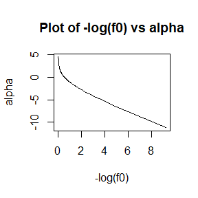

```r
#生成 f0 的序列
f0 <- seq(0.0001, 0.99, length = 100)

# 初始化存储 alphas 的向量
alphas <- numeric(length(f0))

# 循环计算 alpha
for (i in 1:length(f0)) {
  alphas[i] <- alpha(N, b1, b2, b3, f0[i])
}

# 绘制图形
plot(-log(f0), alphas, xlab = "-log(f0)", ylab = "alpha", type = "l", main = "Plot of -log(f0) vs alpha")
```

### Ex 9.4

```r
set.seed(1)
# Metropolis采样函数
rw.Metropolis <- function(sigma, x0, N) {
    # 初始化向量存储采样结果
    x <- numeric(N)
    x[1] <- x0
    # 初始化接受次数
    k <- 0
    # 生成均匀分布的随机数
    u <- runif(N)
    # Metropolis采样过程
    for (i in 2:N) {
        # 从正态分布生成候选样本
        y <- rnorm(1, x[i-1], sigma)
        # 判断是否接受候选样本
        if (u[i] <= exp(abs(x[i-1]) - abs(y))) {
            x[i] <- y
            k <- k + 1
        } else {
            x[i] <- x[i-1]
        }
    }
    # 返回结果
    return(list(x = x, k = k))
}

N <- 2000
sigma <- c(.05, .5, 2.5,  16)

x0 <- 25
rw1 <- rw.Metropolis(sigma[1], x0, N)
rw2 <- rw.Metropolis(sigma[2], x0, N)
rw3 <- rw.Metropolis(sigma[3], x0, N)
rw4 <- rw.Metropolis(sigma[4], x0, N)

#计算每个链条的接受率
data.frame(sigma=sigma,accept.rate=c(rw1$k, rw2$k, rw3$k, rw4$k)/N)
```

```
##   sigma accept.rate
## 1  0.05      0.9790
## 2  0.50      0.8300
## 3  2.50      0.4820
## 4 16.00      0.0915
```

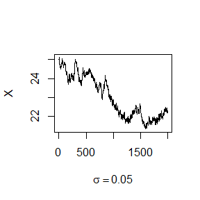

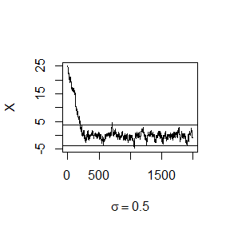

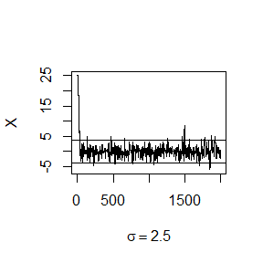

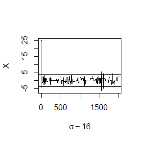

```r
rline <- c(-qexp(.975),qexp(.975))
rw <- cbind(rw1$x, rw2$x, rw3$x,rw4$x)
for (j in 1:4) {
    plot(rw[, j], type = "l", xlab = bquote(sigma == .(round(sigma[j], 3))), ylab = "X", ylim = range(rw[, j]))
    abline(h = rline)
}
```

以前500次为预烧期，比较Q-Q图和直方图如下

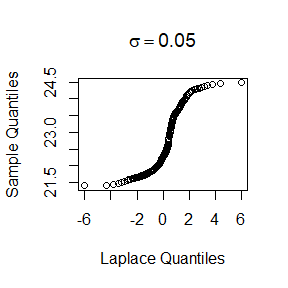

```r
# 生成概率点
p <- ppoints(200)

# 生成Laplace分布的分位数
y <- qexp(p, 1)
z <- c(-rev(y), y)

# 从每个Metropolis采样结果中提取一部分样本
y1 <- rw1$x[501:N]
y2 <- rw2$x[501:N]
y3 <- rw3$x[501:N]
y4 <- rw4$x[501:N]


# 绘制Q-Q图
Q1 <- quantile(y1, p)
qqplot(z, Q1, main = bquote(sigma == .(round(sigma[1], 3))), xlab = "Laplace Quantiles", ylab = "Sample Quantiles")
abline(0, 1)
```

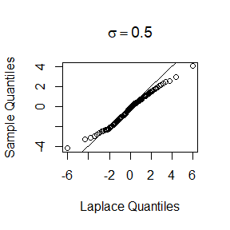

```r
Q2 <- quantile(y2, p)
qqplot(z, Q2, main = bquote(sigma == .(round(sigma[2], 3))), xlab = "Laplace Quantiles", ylab = "Sample Quantiles")
abline(0, 1)
```

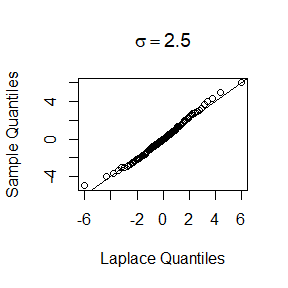

```r
Q3 <- quantile(y3, p)
qqplot(z, Q3, main = bquote(sigma == .(round(sigma[3], 3))), xlab = "Laplace Quantiles", ylab = "Sample Quantiles")
abline(0, 1)
```

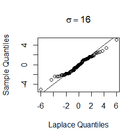

```r
Q4 <- quantile(y4, p)
qqplot(z, Q4, main = bquote(sigma == .(round(sigma[4], 3))), xlab = "Laplace Quantiles", ylab = "Sample Quantiles")
abline(0, 1)
```

从QQ图来看，$\sigma=2.5$时样本分位数和理论分位数差别最小，综上，第三条链收敛效果最好。

### Ex 9.7

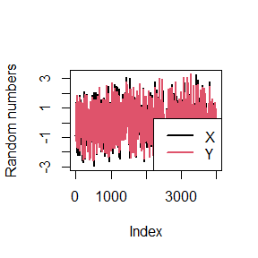

```r
# 初始化常量和参数
N <- 5000    # 链的长度
burn <- 1000  # 预烧期长度
X <- matrix(0, N, 2)
rho <- 0.9   # 相关性
mu1 <- 0
mu2 <- 0
sigma1 <- 1
sigma2 <- 1
s1 <- sqrt(1 - rho^2) * sigma1
s2 <- sqrt(1 - rho^2) * sigma2

# 生成链
X[1, ] <- c(mu1, mu2)  # 初始化
for (i in 2:N) {
  x2 <- X[i - 1, 2]
  m1 <- mu1 + rho * (x2 - mu2) * sigma1 / sigma2
  X[i, 1] <- rnorm(1, m1, s1)
  x1 <- X[i, 1]
  m2 <- mu2 + rho * (x1 - mu1) * sigma2 / sigma1
  X[i, 2] <- rnorm(1, m2, s2)
}
b <- burn + 1
x <- X[b:N, ]

# 绘制图形
plot(x[, 1], type = 'l', col = 1, lwd = 2, xlab = 'Index', ylab = 'Random numbers')
lines(x[, 2], col = 2, lwd = 2)
legend('bottomright', c(expression(X), expression(Y)), col = 1:2, lwd = 2)
```

```r
X <- x[, 1]
Y <- x[, 2]
fit <- lm(Y ~ X)
summary(fit)
```

```
##
## Call:
## lm(formula = Y ~ X)
##
## Residuals:
##      Min       1Q   Median       3Q      Max
## -1.60570 -0.29159 -0.00268  0.28844  1.59143
##
## Coefficients:
##             Estimate Std. Error t value Pr(>|t|)
## (Intercept) 0.004208   0.006873   0.612     0.54
## X           0.896242   0.006961 128.749   <2e-16 ***
## ---
## Signif. codes:  0 '***' 0.001 '**' 0.01 '*' 0.05 '.' 0.1 ' ' 1
##
## Residual standard error: 0.4342 on 3998 degrees of freedom
## Multiple R-squared:  0.8057, Adjusted R-squared:  0.8056
## F-statistic: 1.658e+04 on 1 and 3998 DF,  p-value: < 2.2e-16
```

可以看到,数据被线性模型拟合得很好。下面通过正态性和常值方差来检查模型残差。

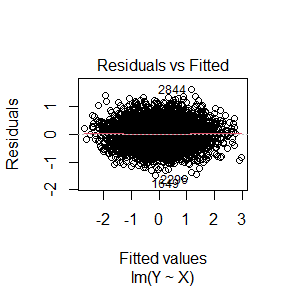

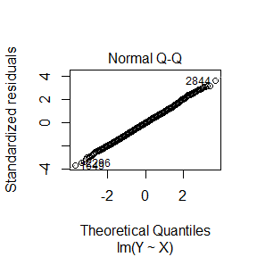

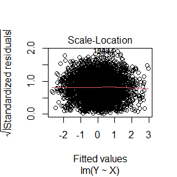

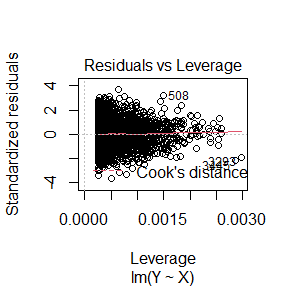

```r
plot(fit)
```

从Q-Q图可以看出和散点图可看出，残差是正态的，残差方差恒定，不是异方差的。

### Ex 9.10

Example9.8中的函数Gelman.Rubin如下，它计算了诊断统计量

```r
Gelman.Rubin <- function(psi) {
# psi[i,j] is the statistic psi(X[i,1:j])
# for chain in i-th row of X
psi <- as.matrix(psi)
n <- ncol(psi)
k <- nrow(psi)
psi.means <- rowMeans(psi) #row means
B <- n * var(psi.means) #between variance est.
psi.w <- apply(psi, 1, "var") #within variances
W <- mean(psi.w) #within est.
v.hat <- W*(n-1)/n + (B/n) #upper variance est.
r.hat <- v.hat / W #G-R statistic
return(r.hat)
}

# 定义概率密度函数
f <- function(x, sigma) {
  if (x < 0)
    return(0)
  stopifnot(sigma > 0)
  return((x/sigma^2) * exp(-x^2/(2 * sigma^2)))
}

# Metropolis-Hastings链生成函数
Rayleigh.MH.chain <- function(sigma, m, x0) {
  x <- numeric(m)
  x[1] <- x0
  u <- runif(m)
  for (i in 2:m) {
    xt <- x[i - 1]
    y <- rchisq(1, df = xt)
    num <- f(y, sigma) * dchisq(xt, df = y)
    den <- f(xt, sigma) * dchisq(y, df = xt)
    if (u[i] <= num/den)
      x[i] <- y
    else x[i] <- xt
  }
  return(x)
}

# 设定参数
sigma <- 4
x0 <- c(1/sigma^2, 1/sigma, sigma^2, sigma^3)
k <- 4
m <- 2000
X <- matrix(0, nrow = k, ncol = m)

# 生成Metropolis-Hastings链
for (i in 1:k) X[i, ] <- Rayleigh.MH.chain(sigma, m, x0[i])

# 计算路径的累积均值
psi <- t(apply(X, 1, cumsum))
for (i in 1:nrow(psi)) psi[i, ] <- psi[i, ] / (1:ncol(psi))

# 计算 Gelman-Rubin 统计量
rhat <- Gelman.Rubin(psi)

# 打印结果
cat("Gelman-Rubin 统计量：", rhat, "\n")
```

```
## Gelman-Rubin 统计量： 1.136212
```

使用”coda”程序包通过Gelman-Rubin方法检验链条收敛性

```r
# 导入 coda 包
library(coda)

# 将每个链转换为 coda::mcmc 对象
X1 <- as.mcmc(X[1, ])
X2 <- as.mcmc(X[2, ])
X3 <- as.mcmc(X[3, ])
X4 <- as.mcmc(X[4, ])

# 将所有链组成 mcmc.list
Y <- mcmc.list(X1, X2, X3, X4)

# 打印 Gelman-Rubin 统计量
print(gelman.diag(Y))
```

```
## Potential scale reduction factors:
##
##      Point est. Upper C.I.
## [1,]       1.01       1.02
```

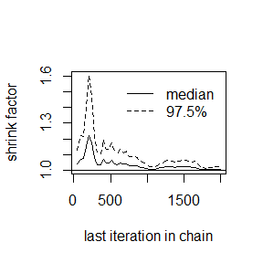

```r
# 绘制 Gelman-Rubin 统计量的图形
gelman.plot(Y, col = c(1, 1))
```

## homework 8

### question 1

直接用观测数据的MLE

```r
# 区间观测数据
data <- matrix(c(11, 8, 27, 13, 16, 0, 23, 10, 24, 2,
                 12, 9, 28, 14, 17, 1, 24, 11, 25, 3), ncol = 2, byrow = FALSE)
logL <- function(lambda) {
  log_likelihood<-sum((data[,2]*exp(-lambda*data[,2])-data[,1]*exp(-lambda*data[,1]))/(exp(-lambda*data[,1])-exp(-lambda*data[,2])))
  return(log_likelihood)
}

solution <- uniroot(logL, c(0, 20))

print(paste("Lambda 的 MLE 数值解为:", round(solution$root,4)))
```

```
## [1] "Lambda 的 MLE 数值解为: 0.072"
```

EM算法

```r
# E-M 算法
n <- nrow(data)
E_step <- function(lambda){
  sum(lambda*(data[,1]*exp(-lambda*data[,1])-data[,2]*exp(-lambda*data[,2]))/(exp(-lambda*data[,1])-exp(-lambda*data[,2])))
}
M_step <- function(lambda){
  n*lambda/(E_step(lambda)+n)
}
lambda <- 1 #初始值
iter <- 1
epsilon<-1e-6
criteria<-1e10
while (criteria>epsilon && iter < 1000) {
  lambda_new <- M_step(lambda)
  iter <- iter+1
  criteria<-abs(lambda_new-lambda)
  lambda <- lambda_new
}
print(paste("E-M算法得到的Lambda的MLE解为:", round(lambda_new,3)))
```

```
## [1] "E-M算法得到的Lambda的MLE解为: 0.072"
```

### question2:11.8

```r
solve.game <- function(A) {
  min.A <- min(A)
  A <- A - min.A
  max.A <- max(A)
  A <- A/max(A)
  m <- nrow(A)
  n <- ncol(A)
  it <- n^3
  a <- c(rep(0, m), 1)
  A1 <- -cbind(t(A), rep(-1, n))
  b1 <- rep(0, n)
  A3 <- t(as.matrix(c(rep(1, m), 0)))
  b3 <- 1
  sx <- simplex(a = a, A1 = A1, b1 = b1, A3 = A3, b3 = b3,
                maxi = TRUE, n.iter = it)
  a <- c(rep(0, n), 1)
  A1 <- cbind(A, rep(-1, m))
  b1 <- rep(0, m)
  A3 <- t(as.matrix(c(rep(1, n), 0)))
  b3 <- 1
  sy <- simplex(a = a, A1 = A1, b1 = b1, A3 = A3, b3 = b3,
                maxi = FALSE, n.iter = it)
  soln <- list(A = A * max.A + min.A, x = sx$soln[1:m],
               y = sy$soln[1:n], v = sx$soln[m + 1] * max.A + min.A)
  soln
}

# 示例输入数据
A <- matrix(c(0, -2, -2, 3, 0, 0, 4, 0, 0,
              2, 0, 0, 0, -3, -3, 4, 0, 0,
              2, 0, 0, 3, 0, 0, 0, -4, -4,
              -3, 0, -3, 0, 4, 0, 0, 5, 0, 0,
              3, 0, -4, 0, -4, 0, 5, 0, 0, 3,
              0, 0, 4, 0, -5, 0, -5, -4, -4, 0,
              0, 0, 5, 0, 0, 6, 0, 0, 4, -5, -5,
              0, 0, 0, 6, 0, 0, 4, 0, 0, 5, -6, -6, 0), 9, 9)


library(boot)
B <- A + 2
s <- solve.game(B)
s$v  # 输出解决方案的值
```

```
## x10
##   2
```

```r
round(cbind(s$x, s$y), 7)
```

```
##         [,1]      [,2]
## x1 0.0000000 0.0000000
## x2 0.0000000 0.0000000
## x3 0.4098361 0.4098361
## x4 0.0000000 0.0000000
## x5 0.3278689 0.3278689
## x6 0.0000000 0.0000000
## x7 0.2622951 0.2622951
## x8 0.0000000 0.0000000
## x9 0.0000000 0.0000000
```

```r
round(s$x * 61, 7)
```

```
## x1 x2 x3 x4 x5 x6 x7 x8 x9
##  0  0 25  0 20  0 16  0  0
```

游戏B的极值点为原游戏A的其中一个极值点(11.15)。

## homework 9

### 2.1.3 Exercise 4 (Pages 19 Advanced in R)

Why do you need to use unlist() to convert a list to an atomic vector? Why doesn’t as.vector() work?

Answer：unlist()函数可以将一个列表转换为一个原子向量，因为它会将列表中的所有元素展开并组合成一个单一的向量。而as.vector()函数在这种情况下并不会产生相同的效果。因为as.vector()函数在处理列表时通常只是确认对象是否已经是向量，如果对象是列表，它通常只是返回原对象，不会展开列表中的元素。

### 2.3.1 Exercise 1, 2 (Pages 26 Advanced in R)

1. What does dim() return when applied to a vector?

Answer：当应用于一个向量时，dim()函数会返回NULL，因为向量是一维的，没有维度信息。

2. If is.matrix(x) is TRUE, what will is.array(x) return?

Answer：如果 is.matrix(x) 返回 TRUE，那么 is.array(x) 也会返回 TRUE。因为在 R 中，矩阵是具有两个维度的特定类型的数组，所以如果某物被识别为矩阵，它也自然符合数组的条件。

### 2.4.5 Exercise 2, 3 (Pages 30 Advanced in R)

2. What does as.matrix() do when applied to a data frame with columns of different types?

Answer：当应用于具有不同类型列的数据框时，as.matrix()将尝试将数据框转换为矩阵。由于矩阵要求所有元素类型相同，因此在转换时，as.matrix() 会尝试将数据框中的所有列转换为同一种类型。通常情况下，这意味着将所有列转换为具有最灵活数据类型的统一类型，例如将字符型数据转换为因子或将字符型数据转换为数值型数据。

3. Can you have a data frame with 0 rows? What about 0 columns?

```r
# 可以
a<-data.frame(x=0.1,y=0.2)
a[FALSE,]
```

```
## [1] x y
## <0 行> (或0-长度的row.names)
```

```r
a[,FALSE]
```

```
## data frame with 0 columns and 1 row
```

```r
a[FALSE,FALSE]
```

```
## data frame with 0 columns and 0 rows
```

### Exercises 2 (page 204, Advanced R)

The function below scales a vector so it falls in the range [0,1]. How would you apply it to every column of a data frame?How would you apply it to every numeric column in a data frame?

```r
scale01 <- function(x) {
rng <- range(x, na.rm = TRUE)
(x - rng[1]) / (rng[2] - rng[1])
}
```

使用 apply() 函数来对数据框的每一列应用这个函数。对于所有的数值列，先使用 lapply() 筛选出数值列，然后再利用 apply() 应用 scale01() 函数。

```r
# 先构造两个dataframe
# 数值数据框
x<-1:5
y<-6:10
z<-c("A","B","C","D","E")
df<-data.frame(x=x,y=y)
# 混合数据框
mix.df<-data.frame(x=x,y=y,z=z)

# 对于数据框的所有列应用函数
apply(df, 2, scale01)
```

```
##         x    y
## [1,] 0.00 0.00
## [2,] 0.25 0.25
## [3,] 0.50 0.50
## [4,] 0.75 0.75
## [5,] 1.00 1.00
```

```r
# 对于数据框的数值列应用函数
data.frame(lapply(mix.df, function(x) if (is.numeric(x)) scale01(x) else x))
```

```
##      x    y z
## 1 0.00 0.00 A
## 2 0.25 0.25 B
## 3 0.50 0.50 C
## 4 0.75 0.75 D
## 5 1.00 1.00 E
```

### Exercises 1 (page 213, Advanced R)

1. Use vapply() to:
1. Compute the standard deviation of every column in a numeric data frame.
2. Compute the standard deviation of every numeric column in a mixed data frame. (Hint: you’ll need to use vapply() twice.)
3. 计算数值数据框中每一列的标准差：

```r
# 仍然利用Exercises 2 (page 204, Advanced R)构造的数据框
vapply(df, sd, numeric(1))
```

```
##        x        y
## 1.581139 1.581139
```

2. 计算混合数据框中的每个数值列的标准差：

```r
# 仍然利用Exercises 2 (page 204, Advanced R)构造的数据框
vapply(mix.df[vapply(mix.df, is.numeric, logical(1))],sd, numeric(1))
```

```
##        x        y
## 1.581139 1.581139
```

### question 2

Consider Exercise 9.8 (pages 278, Statistical Computing with R). (Hint: Refer to the first example of Case studies section)

• Write an R function.

• Write an Rcpp function.

• Compare the computation time of the two functions with the function “microbenchmark”.

r code

```r
gibbsR <- function(N,a,b,n) {
  mat <- matrix(nrow = N, ncol = 2)
  x <- y <- 0
  for (i in 1:N) {
    x <- rbinom(1, n, y)
    y <- rbeta(1, x+a, n-x+b)
    mat[i, ] <- c(x, y)
  }
  mat
}
```

Rcpp code

```r
NumericMatrix gibbsC(int N,  int a, int b, int n) {
  NumericMatrix mat(N, 2);
  double x = 0, y = 0;
  for(int i = 0; i < N; i++) {
    x = rbinom(1, n, y)[0];
    y = rbeta(1, x+a, n-x+b)[0];
    mat(i, 0) = x;
    mat(i, 1) = y;
  }
  return(mat);
}
```

```r
library(Rcpp)
library(microbenchmark)
library(SA23204168)
ts <- microbenchmark(gibbsR=gibbsR(100,2,3,10),gibbsC=gibbsC(100,2,3,10))
#summary(ts)[,c(1,3,5,6)]
```